# Candy Case Study – Lidl Data & AI

Author

Chris-Gabriel Islam

Published

July 14, 2025

# 🎯 Goal of the analysis

The goal of the analysis is to determine the properties of successful candies based on a consumer survey. Using this information, we want to give a recommendation for extending the range of candies by the own brand of Lidl.

# 📦 Data preparation

We do not load the original data by FiveThirtyEight but an edited one. In the edited data set, we added a new variable `producer` that indicates the producing company of the candy. We also renamed the variable `winpercent` to `winperc` to better highlight that this variable is a percentage value rather than a percentile rank. Lastly, we removed the variable `sugarpercent` and added a new variable `sugarperc` that indicates the sugar content of the candy in percent. This variable is necessary as the variable `sugarpercent` in the original data set is faulty. For example, Nestle Crunch has 51.4 % sugar and a percentile rank of 0.313 but Sour Patch Kids have 64 % sugar but a lower percentile rank of 0.069. On the contrary, Fun Dip has 83.3 % sugar and a percentile rank of 0.7319. Hence, the order of `sugarpercent` seems incorrect.

```r
# Clean environment
rm(list = ls())

# Load packages
library(tidyverse) # for data manipulation
library(ggplot2) # for plotting
library(here) # for referecing
library(BMA) # for BMA
library(corrplot) # for correlation plots
library(xgboost) # for XGBoost Regression
library(psych) # for principal component analysis
library(ranger) # for random forest
library(caret) # for model training
library(scales) # for scaling variables
library(lme4) # for random effects regression
library(lmtest) # for reset test
library(car) # for VIF
library(fastDummies) # for dummy creation
library(shapviz) # for SHAP values
library(kernelshap) # for SHAP values
library(glmnet) # for LASSO regression
library(kableExtra) # for nicer tables

# Import data
candy_data <- read_csv(here::here("data", "candy-data_edit_2025.csv"))
```

## Overview about the data

```r
kable(glimpse(candy_data), digits = 3)
```

```
Rows: 85
Columns: 14
$ competitorname   <chr> "100 Grand", "3 Musketeers", "One dime", "One quarter…
$ producer         <chr> "Ferrara", "Mars", NA, NA, "Perfetti", "Hershey", "Fe…
$ chocolate        <dbl> 1, 1, 0, 0, 0, 1, 1, 0, 0, 0, 1, 0, 0, 0, 0, 0, 0, 0,…
$ fruity           <dbl> 0, 0, 0, 0, 1, 0, 0, 0, 0, 1, 0, 1, 1, 1, 1, 1, 1, 1,…
$ caramel          <dbl> 1, 0, 0, 0, 0, 0, 1, 0, 0, 1, 0, 0, 0, 0, 0, 0, 0, 0,…
$ peanutyalmondy   <dbl> 0, 0, 0, 0, 0, 1, 1, 1, 0, 0, 0, 0, 0, 0, 0, 0, 0, 0,…
$ nougat           <dbl> 0, 1, 0, 0, 0, 0, 1, 0, 0, 0, 1, 0, 0, 0, 0, 0, 0, 0,…
$ crispedricewafer <dbl> 1, 0, 0, 0, 0, 0, 0, 0, 0, 0, 0, 0, 0, 0, 0, 0, 0, 0,…
$ hard             <dbl> 0, 0, 0, 0, 0, 0, 0, 0, 0, 0, 0, 0, 0, 0, 1, 0, 1, 1,…
$ bar              <dbl> 1, 1, 0, 0, 0, 1, 1, 0, 0, 0, 1, 0, 0, 0, 0, 0, 0, 0,…
$ pluribus         <dbl> 0, 0, 0, 0, 0, 0, 0, 1, 1, 0, 0, 1, 1, 1, 0, 1, 0, 1,…
$ pricepercent     <dbl> 0.860, 0.511, 0.116, 0.511, 0.511, 0.767, 0.767, 0.51…
$ winperc          <dbl> 66.97173, 67.60294, 32.26109, 46.11650, 52.34146, 50.…
$ sugarperc        <dbl> 0.5238095, 0.6801471, NA, NA, 0.5588235, 0.4666667, 0…
```

| competitorname | producer | chocolate | fruity | caramel | peanutyalmondy | nougat | crispedricewafer | hard | bar | pluribus | pricepercent | winperc | sugarperc |
| --- | --- | --- | --- | --- | --- | --- | --- | --- | --- | --- | --- | --- | --- |
| 100 Grand | Ferrara | 1 | 0 | 1 | 0 | 0 | 1 | 0 | 1 | 0 | 0.860 | 66.972 | 0.524 |
| 3 Musketeers | Mars | 1 | 0 | 0 | 0 | 1 | 0 | 0 | 1 | 0 | 0.511 | 67.603 | 0.680 |
| One dime | NA | 0 | 0 | 0 | 0 | 0 | 0 | 0 | 0 | 0 | 0.116 | 32.261 | NA |
| One quarter | NA | 0 | 0 | 0 | 0 | 0 | 0 | 0 | 0 | 0 | 0.511 | 46.117 | NA |
| Air Heads | Perfetti | 0 | 1 | 0 | 0 | 0 | 0 | 0 | 0 | 0 | 0.511 | 52.341 | 0.559 |
| Almond Joy | Hershey | 1 | 0 | 0 | 1 | 0 | 0 | 0 | 1 | 0 | 0.767 | 50.348 | 0.467 |
| Baby Ruth | Ferrara | 1 | 0 | 1 | 1 | 1 | 0 | 0 | 1 | 0 | 0.767 | 56.915 | 0.520 |
| Boston Baked Beans | Ferrara | 0 | 0 | 0 | 1 | 0 | 0 | 0 | 0 | 1 | 0.511 | 23.418 | 0.667 |
| Candy Corn | Ferrara | 0 | 0 | 0 | 0 | 0 | 0 | 0 | 0 | 1 | 0.325 | 38.011 | 0.710 |
| Caramel Apple Pops | Tootsie | 0 | 1 | 1 | 0 | 0 | 0 | 0 | 0 | 0 | 0.325 | 34.518 | 0.556 |
| Charleston Chew | Tootsie | 1 | 0 | 0 | 0 | 1 | 0 | 0 | 1 | 0 | 0.511 | 38.975 | 0.579 |
| Chewey Lemonhead Fruit Mix | Ferrara | 0 | 1 | 0 | 0 | 0 | 0 | 0 | 0 | 1 | 0.511 | 36.018 | 0.727 |
| Chiclets | Mondelez | 0 | 1 | 0 | 0 | 0 | 0 | 0 | 0 | 1 | 0.325 | 24.525 | 0.667 |
| Dots | Tootsie | 0 | 1 | 0 | 0 | 0 | 0 | 0 | 0 | 1 | 0.511 | 42.272 | 0.525 |
| Dum Dums | Spangler | 0 | 1 | 0 | 0 | 0 | 0 | 1 | 0 | 0 | 0.034 | 39.461 | 0.733 |
| Fruit Chews | Tootsie | 0 | 1 | 0 | 0 | 0 | 0 | 0 | 0 | 1 | 0.034 | 43.089 | 0.500 |
| Fun Dip | Ferrara | 0 | 1 | 0 | 0 | 0 | 0 | 1 | 0 | 0 | 0.325 | 39.186 | 0.833 |
| Gobstopper | Ferrara | 0 | 1 | 0 | 0 | 0 | 0 | 1 | 0 | 1 | 0.453 | 46.783 | 0.812 |
| Haribo Gold Bears | Haribo | 0 | 1 | 0 | 0 | 0 | 0 | 0 | 0 | 1 | 0.465 | 57.120 | 0.460 |
| Haribo Happy Cola | Haribo | 0 | 0 | 0 | 0 | 0 | 0 | 0 | 0 | 1 | 0.465 | 34.159 | 0.560 |
| Haribo Sour Bears | Haribo | 0 | 1 | 0 | 0 | 0 | 0 | 0 | 0 | 1 | 0.465 | 51.412 | 0.516 |
| Haribo Twin Snakes | Haribo | 0 | 1 | 0 | 0 | 0 | 0 | 0 | 0 | 1 | 0.465 | 42.179 | 0.470 |
| HersheyÕs Kisses | Hershey | 1 | 0 | 0 | 0 | 0 | 0 | 0 | 0 | 1 | 0.093 | 55.375 | 0.524 |
| HersheyÕs Krackel | Hershey | 1 | 0 | 0 | 0 | 0 | 1 | 0 | 1 | 0 | 0.918 | 62.284 | 0.543 |
| HersheyÕs Milk Chocolate | Hershey | 1 | 0 | 0 | 0 | 0 | 0 | 0 | 1 | 0 | 0.918 | 56.491 | 0.576 |
| HersheyÕs Special Dark | Hershey | 1 | 0 | 0 | 0 | 0 | 0 | 0 | 1 | 0 | 0.918 | 59.236 | 0.533 |
| Jawbusters | Ferrara | 0 | 1 | 0 | 0 | 0 | 0 | 1 | 0 | 1 | 0.511 | 28.127 | 0.833 |
| Junior Mints | Tootsie | 1 | 0 | 0 | 0 | 0 | 0 | 0 | 0 | 1 | 0.511 | 57.219 | 0.860 |
| Kit Kat | Hershey | 1 | 0 | 0 | 0 | 0 | 1 | 0 | 1 | 0 | 0.511 | 76.769 | 0.548 |
| Laffy Taffy | Ferrara | 0 | 1 | 0 | 0 | 0 | 0 | 0 | 0 | 0 | 0.116 | 41.390 | 0.552 |

[output cut: 55 more lines]

## Clean and edit data

We remove one dime and one quarter as they are not really candy and might bias the regression results.

```r
candy_data <- candy_data[!(candy_data$competitorname %in% c("One dime", "One quarter")), ]
```

Because we deleted data, we have to readjust the percentile ranks of `pricepercent`.

```r
# Define function
percentile_ranked <- function(a_vector, value) {
  length(sort(a_vector)[a_vector < value]) / length(a_vector)
}
# Apply function
b <- candy_data$pricepercent
candy_data$pricepercent <- sapply(candy_data$pricepercent, percentile_ranked, a_vector = b)
```

We also add a new variable which is the number of features per candy for better selecting the best features later on.

```r
candy_data <- candy_data %>% mutate(
  num_features = rowSums(dplyr::select(., -competitorname, -producer, -winperc, -pricepercent, -sugarperc))
)
```

# 📊 Exploratory analysis

## Summary statistics

First, we give summary statistics for the numeric variables.

```r
kable(psych::describe(candy_data %>% dplyr::select(-producer, -competitorname), ), digits = 3)
```

|  | vars | n | mean | sd | median | trimmed | mad | min | max | range | skew | kurtosis | se |
| --- | --- | --- | --- | --- | --- | --- | --- | --- | --- | --- | --- | --- | --- |
| chocolate | 1 | 83 | 0.446 | 0.500 | 0.000 | 0.433 | 0.000 | 0.000 | 1.000 | 1.000 | 0.214 | -1.978 | 0.055 |
| fruity | 2 | 83 | 0.458 | 0.501 | 0.000 | 0.448 | 0.000 | 0.000 | 1.000 | 1.000 | 0.166 | -1.996 | 0.055 |
| caramel | 3 | 83 | 0.169 | 0.377 | 0.000 | 0.090 | 0.000 | 0.000 | 1.000 | 1.000 | 1.738 | 1.033 | 0.041 |
| peanutyalmondy | 4 | 83 | 0.169 | 0.377 | 0.000 | 0.090 | 0.000 | 0.000 | 1.000 | 1.000 | 1.738 | 1.033 | 0.041 |
| nougat | 5 | 83 | 0.084 | 0.280 | 0.000 | 0.000 | 0.000 | 0.000 | 1.000 | 1.000 | 2.938 | 6.711 | 0.031 |
| crispedricewafer | 6 | 83 | 0.084 | 0.280 | 0.000 | 0.000 | 0.000 | 0.000 | 1.000 | 1.000 | 2.938 | 6.711 | 0.031 |
| hard | 7 | 83 | 0.181 | 0.387 | 0.000 | 0.104 | 0.000 | 0.000 | 1.000 | 1.000 | 1.630 | 0.664 | 0.042 |
| bar | 8 | 83 | 0.253 | 0.437 | 0.000 | 0.194 | 0.000 | 0.000 | 1.000 | 1.000 | 1.116 | -0.764 | 0.048 |
| pluribus | 9 | 83 | 0.530 | 0.502 | 1.000 | 0.537 | 0.000 | 0.000 | 1.000 | 1.000 | -0.119 | -2.010 | 0.055 |
| pricepercent | 10 | 83 | 0.464 | 0.289 | 0.458 | 0.459 | 0.322 | 0.000 | 0.976 | 0.976 | 0.127 | -1.201 | 0.032 |
| winperc | 11 | 83 | 50.585 | 14.749 | 48.983 | 50.102 | 15.202 | 22.445 | 84.180 | 61.735 | 0.295 | -0.689 | 1.619 |
| sugarperc | 12 | 83 | 0.605 | 0.165 | 0.559 | 0.596 | 0.133 | 0.188 | 1.000 | 0.812 | 0.389 | 0.021 | 0.018 |
| num_features | 13 | 83 | 2.373 | 0.893 | 2.000 | 2.313 | 0.000 | 1.000 | 5.000 | 4.000 | 0.835 | 0.991 | 0.098 |

Then, we show a table for the producer variable.

```r
kable(table(candy_data$producer))
```

| Var1 | Freq |
| --- | --- |
| American Licorice Company | 1 |
| Arcor | 1 |
| Ferrara | 20 |
| Haribo | 4 |
| Hershey | 17 |
| Impact | 1 |
| Just Born | 1 |
| Mars | 14 |
| Mondelez | 4 |
| Perfetti | 1 |
| Spangler | 1 |
| Storck | 1 |
| SweetWorks | 1 |
| Tootsie | 12 |
| Topps | 1 |
| Washburn | 1 |
| Welchs | 1 |
| Zeta | 1 |

As there are many producers that only have one candy in our data set, we group them together.

```r
candy_data$producer <- ifelse(candy_data$producer %in% c("Ferrara", "Haribo", "Hershey", "Mars", "Mondelez", "Tootsie"), candy_data$producer, "Other")
```

## Normality of win percentage

We will use the variable `winpercent` later as the dependent variable. In the best case, this variable is normally distributed. Hence, we plot a histogram and apply a Shapiro-Wilk’s test.

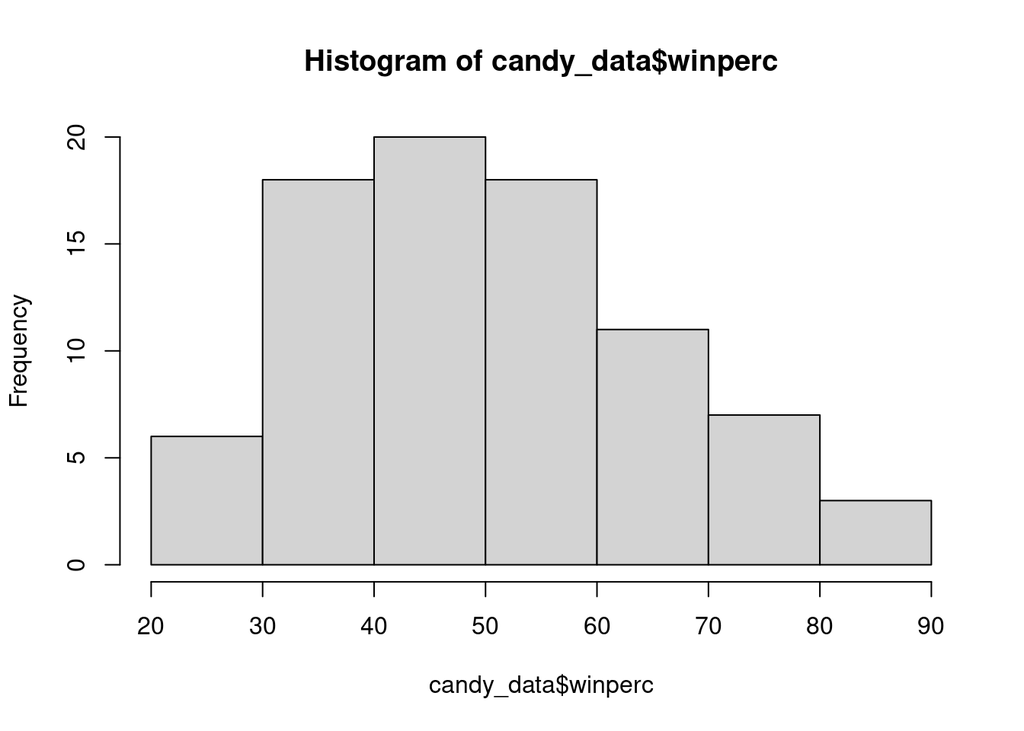

```r
hist(candy_data$winperc)
```

```r
shapiro.test(candy_data$winperc)
```

```
    Shapiro-Wilk normality test

data:  candy_data$winperc
W = 0.97819, p-value = 0.1705
```

The variable seems normally distributed. We won’t apply any transformation to it.

## Win percentage by features

We show the distribution of the variable `winpercent` by different features.

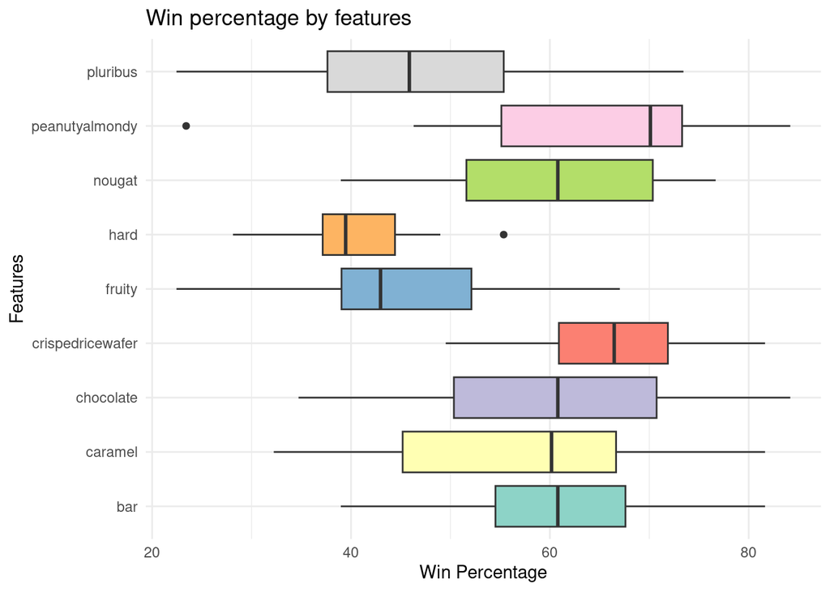

```r
# Visualize boxplots by features except producer, pricepercent, sugarperc and number of features
df_long <- candy_data %>% pivot_longer(cols = -c(competitorname, producer, winperc, num_features, pricepercent, sugarperc), names_to = "feature", values_to = "value")
df_long %>%
  dplyr::select(-competitorname, -producer, -sugarperc) %>%
  filter(value == 1) %>%
  ggplot(aes(x = reorder(feature, value), y = winperc, fill = feature)) +
  geom_boxplot() +
  coord_flip() +
  labs(title = "Win percentage by features", x = "Features", y = "Win Percentage") +
  theme_minimal() +
  scale_fill_brewer(palette = "Set3") +
  theme(legend.position = "none") +
  scale_x_discrete(limits = sort(unique(df_long$feature)))
```

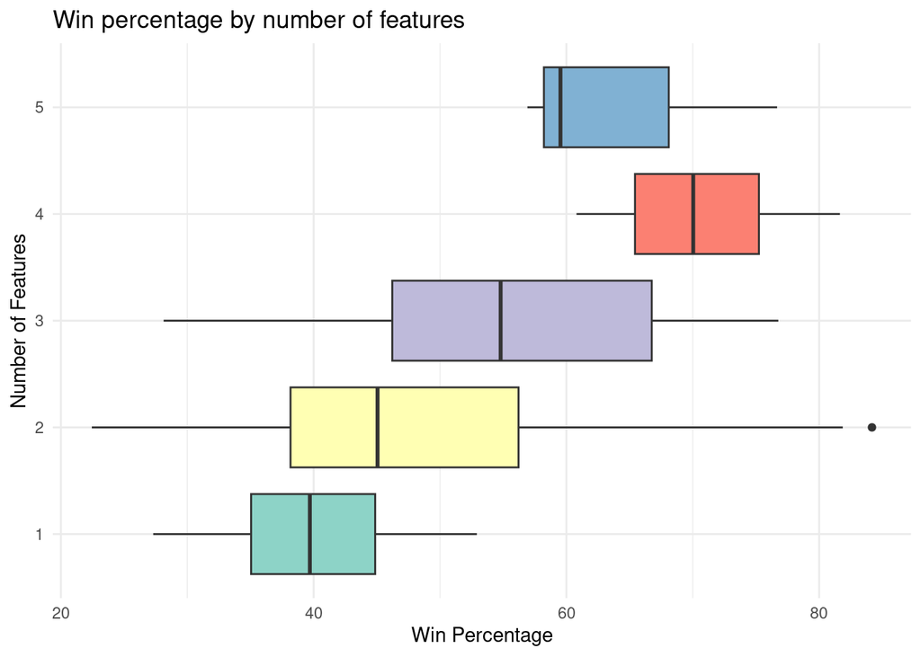

```r
# Visualize boxplots winperc by number of features
ggplot(candy_data, aes(x = reorder(num_features, winperc), y = winperc, fill = as.factor(num_features))) +
  geom_boxplot() +
  coord_flip() +
  labs(title = "Win percentage by number of features", x = "Number of Features", y = "Win Percentage") +
  theme_minimal() +
  scale_fill_brewer(palette = "Set3") +
  theme(legend.position = "none") +
  scale_x_discrete(limits = as.character(sort(unique(candy_data$num_features))))
```

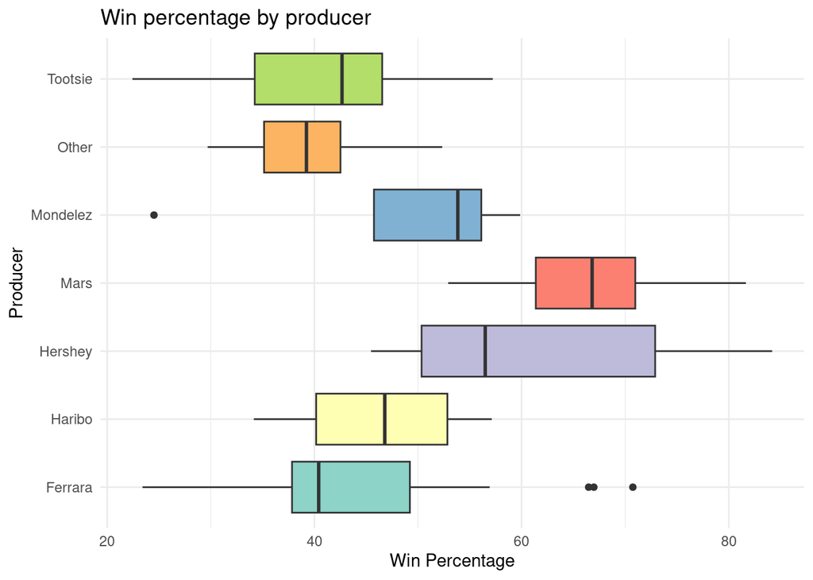

```r
# Visualize boxplots winperc by producer
ggplot(candy_data, aes(x = reorder(producer, winperc), y = winperc, fill = producer)) +
  geom_boxplot() +
  coord_flip() +
  labs(title = "Win percentage by producer", x = "Producer", y = "Win Percentage") +
  theme_minimal() +
  scale_fill_brewer(palette = "Set3") +
  theme(legend.position = "none") +
  scale_x_discrete(limits = sort(unique(candy_data$producer)))
```

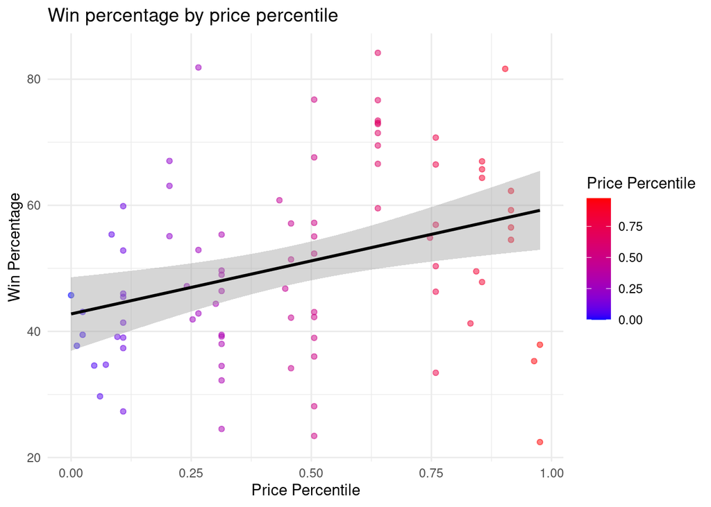

```r
# Visualize winperc by pricepercent
ggplot(candy_data, aes(x = pricepercent, y = winperc)) +
  geom_point(aes(color = pricepercent), alpha = 0.5) +
  geom_smooth(method = "lm", se = TRUE, color = "black") +
  labs(title = "Win percentage by price percentile", x = "Price Percentile", y = "Win Percentage") +
  theme_minimal() +
  scale_color_gradient(low = "blue", high = "red", name = "Price Percentile")
```

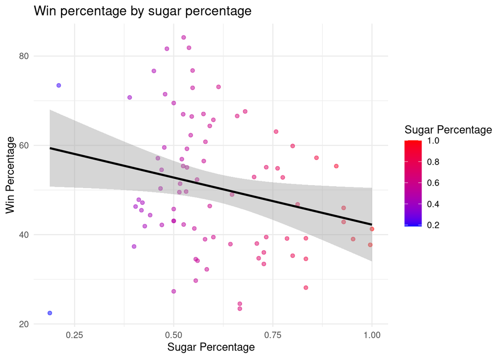

```r
# Visualize winperc by sugarperc
ggplot(candy_data, aes(x = sugarperc, y = winperc)) +
  geom_point(aes(color = sugarperc), alpha = 0.5) +
  geom_smooth(method = "lm", se = TRUE, color = "black") +
  labs(title = "Win percentage by sugar percentage", x = "Sugar Percentage", y = "Win Percentage") +
  theme_minimal() +
  scale_color_gradient(low = "blue", high = "red", name = "Sugar Percentage")
```

Interpretation:

- Hard candy has an overall low win percentage, while candy with nuts (peanuty/almondy) and candy that is cookie-based (crisped rice/wafer/cookie) seems to dominate other features regarding win percentage.
- The highest win percentage distribution is given for candies with four features.
- Mars and Hershey produce candies with the highest popularity.
- The higher the price, the more popular a candy, even though the relation is not strictly linear.
- The sweeter a candy, the less popular a candy, even though the relation is not strictly linear.

## Correlation

Next, we show a correlation plot, indicating the most common combinations of features in our data set.

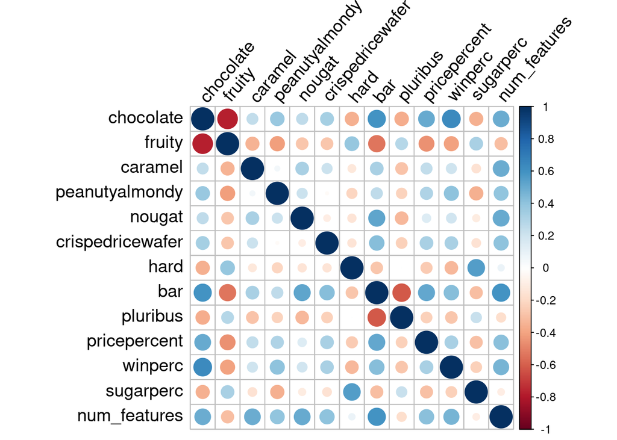

```r
corrplot(as.matrix(cor(na.omit(candy_data %>% dplyr::select(-competitorname, -producer)))),
  tl.col = "black", tl.cex = 1.2, tl.srt = 50
)
```

Here, we see, among others, that chocolate and fruity almost never occur together in our data set. Same holds for pluribus and bar. Additionally, chocolate seems pricier but also more popular.

# 📈 Regression analysis

```r
# Init data
lm_data <- candy_data %>% dplyr::select(-num_features, -competitorname)

# Regression model
lm_model <- lm(winperc ~ . + I(sugarperc^2) + I(pricepercent^2), data = lm_data)
summary(lm_model)
```

```
Call:
lm(formula = winperc ~ . + I(sugarperc^2) + I(pricepercent^2),
    data = lm_data)

Residuals:
     Min       1Q   Median       3Q      Max
-24.0602  -5.4175   0.8756   5.7780  16.8300

Coefficients:
                  Estimate Std. Error t value Pr(>|t|)
(Intercept)        42.2177    14.7044   2.871 0.005565 **
producerHaribo      6.6786     5.7606   1.159 0.250684
producerHershey     9.0879     3.8467   2.363 0.021252 *
producerMars       14.5600     3.7823   3.849 0.000279 ***
producerMondelez    6.4824     5.6012   1.157 0.251506
producerOther       0.2195     3.7194   0.059 0.953132
producerTootsie    -5.3674     3.9184  -1.370 0.175615
chocolate          18.4504     3.9222   4.704 1.44e-05 ***
fruity              7.9155     3.8025   2.082 0.041443 *
caramel             2.9744     3.3914   0.877 0.383793
peanutyalmondy      5.6077     3.7254   1.505 0.137259
nougat             -2.9894     5.1943  -0.576 0.566997
crispedricewafer    6.8445     4.6784   1.463 0.148439
hard               -3.7437     4.1585  -0.900 0.371409
bar                -0.2750     4.6620  -0.059 0.953151
pluribus           -2.1917     3.0530  -0.718 0.475484
pricepercent       23.2423    16.2534   1.430 0.157657
sugarperc         -42.4039    41.6784  -1.017 0.312852
I(sugarperc^2)     40.4443    32.9483   1.228 0.224199
I(pricepercent^2) -28.7928    16.2548  -1.771 0.081340 .
---
Signif. codes:  0 '***' 0.001 '**' 0.01 '*' 0.05 '.' 0.1 ' ' 1

Residual standard error: 9.314 on 63 degrees of freedom
Multiple R-squared:  0.6936,    Adjusted R-squared:  0.6012
F-statistic: 7.507 on 19 and 63 DF,  p-value: 4.87e-10
```

```r
# Test the model
resettest(lm_model)
```

```
    RESET test

data:  lm_model
RESET = 4.3435, df1 = 2, df2 = 61, p-value = 0.01724
```

```r
raintest(lm_model)
```

```
    Rainbow test

data:  lm_model
Rain = 1.4059, df1 = 42, df2 = 21, p-value = 0.2023
```

```r
bptest(lm_model)
```

```
    studentized Breusch-Pagan test

data:  lm_model
BP = 26.546, df = 19, p-value = 0.1157
```

```r
kable(vif(lm_model))
```

|  | GVIF | Df | GVIF^(1/(2*Df)) |
| --- | --- | --- | --- |
| producer | 5.944948 | 6 | 1.160145 |
| chocolate | 3.636705 | 1 | 1.907015 |
| fruity | 3.434204 | 1 | 1.853161 |
| caramel | 1.543190 | 1 | 1.242252 |
| peanutyalmondy | 1.862194 | 1 | 1.364623 |
| nougat | 1.993721 | 1 | 1.411992 |
| crispedricewafer | 1.617351 | 1 | 1.271751 |
| hard | 2.449978 | 1 | 1.565241 |
| bar | 3.930575 | 1 | 1.982568 |
| pluribus | 2.221630 | 1 | 1.490514 |
| pricepercent | 20.792260 | 1 | 4.559853 |
| sugarperc | 44.530439 | 1 | 6.673113 |
| I(sugarperc^2) | 46.619111 | 1 | 6.827819 |
| I(pricepercent^2) | 20.795487 | 1 | 4.560207 |

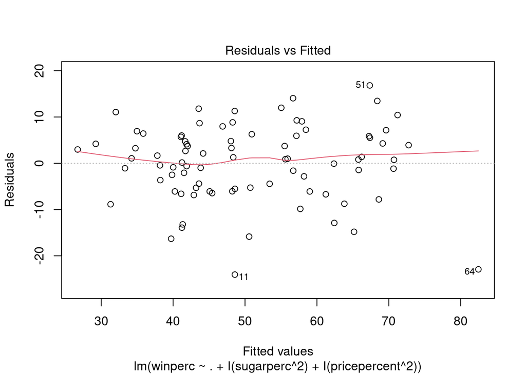

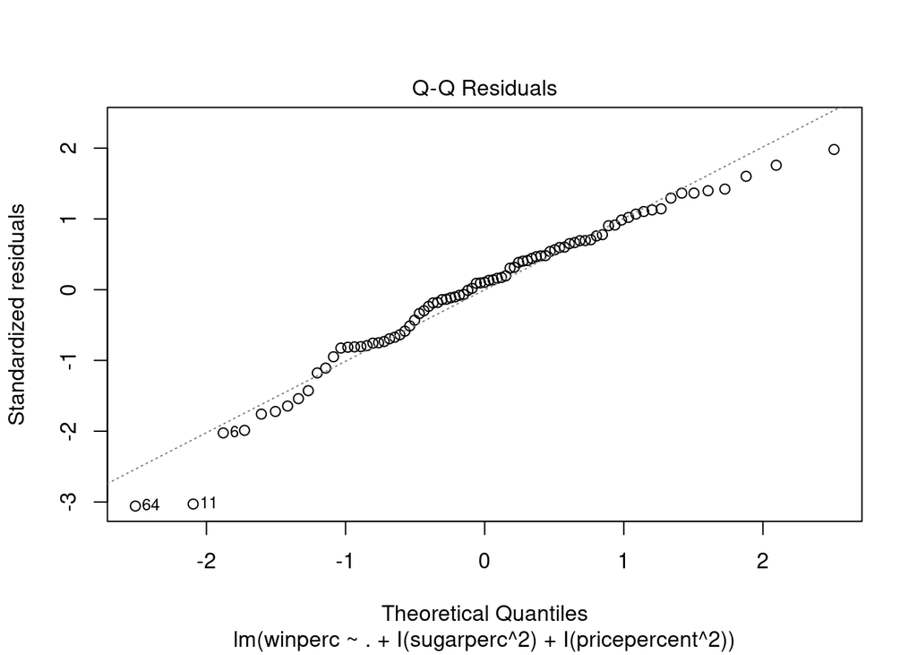

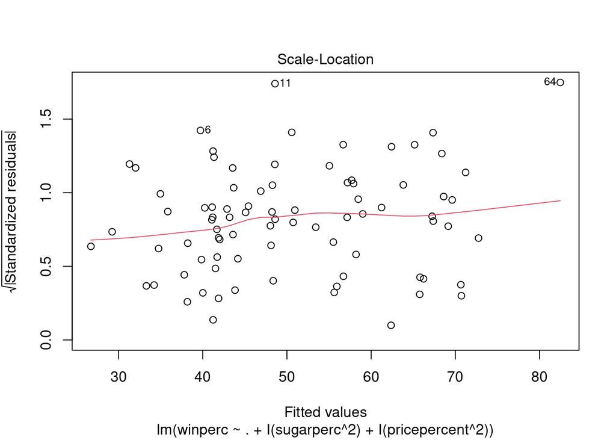

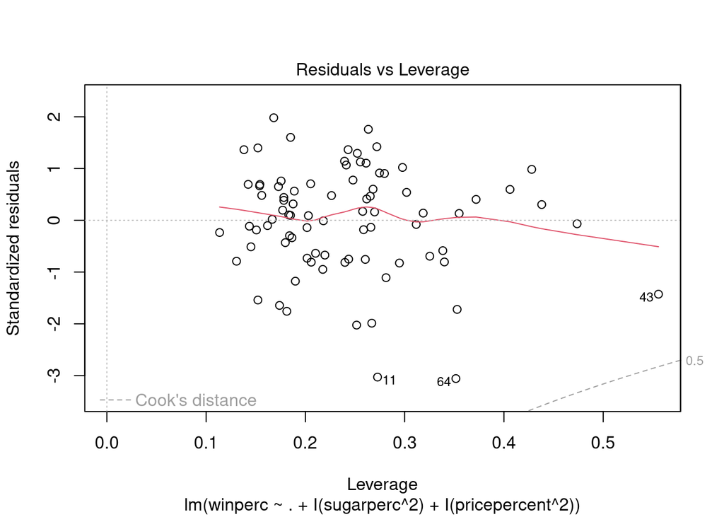

```r
plot(lm_model)
```

```r
# Table of coefficients with 95 % CI
coef_summary <- summary(lm_model)$coefficients
conf_int <- confint(lm_model, level = 0.95)
coef_table <- cbind(
  Estimate = coef_summary[, "Estimate"],
  `Std. Error` = coef_summary[, "Std. Error"],
  `t value` = coef_summary[, "t value"],
  `Pr(>|t|)` = coef_summary[, "Pr(>|t|)"],
  `CI 2.5%` = conf_int[, 1],
  `CI 97.5%` = conf_int[, 2]
)
kable(print(coef_table), digits = 3)
```

```
                     Estimate Std. Error     t value     Pr(>|t|)      CI 2.5%
(Intercept)        42.2177152  14.704410  2.87109211 5.564652e-03   12.8332968
producerHaribo      6.6786226   5.760606  1.15936107 2.506844e-01   -4.8330303
producerHershey     9.0878705   3.846665  2.36253237 2.125173e-02    1.4009239
producerMars       14.5599631   3.782316  3.84948304 2.791920e-04    7.0016068
producerMondelez    6.4823936   5.601152  1.15733220 2.515058e-01   -4.7106155
producerOther       0.2194736   3.719387  0.05900802 9.531325e-01   -7.2131275
producerTootsie    -5.3674237   3.918431 -1.36978906 1.756153e-01  -13.1977829
chocolate          18.4504100   3.922178  4.70412395 1.437449e-05   10.6125633
fruity              7.9154602   3.802489  2.08165215 4.144304e-02    0.3167915
caramel             2.9743840   3.391362  0.87704716 3.837933e-01   -3.8027113
peanutyalmondy      5.6076924   3.725435  1.50524515 1.372586e-01   -1.8369946
nougat             -2.9893838   5.194328 -0.57550924 5.669970e-01  -13.3694202
crispedricewafer    6.8445303   4.678422  1.46299988 1.484388e-01   -2.5045493
hard               -3.7437165   4.158474 -0.90026202 3.714093e-01  -12.0537644
bar                -0.2749895   4.662035 -0.05898487 9.531509e-01   -9.5913230
pluribus           -2.1917107   3.053024 -0.71788183 4.754839e-01   -8.2926929
pricepercent       23.2423349  16.253356  1.43000220 1.576572e-01   -9.2374055
sugarperc         -42.4039087  41.678443 -1.01740625 3.128516e-01 -125.6916317
I(sugarperc^2)     40.4443243  32.948309  1.22750834 2.241986e-01  -25.3976175
I(pricepercent^2) -28.7928157  16.254781 -1.77134447 8.133999e-02  -61.2754027
                    CI 97.5%
(Intercept)        71.602134
producerHaribo     18.190275
producerHershey    16.774817
producerMars       22.118320
producerMondelez   17.675403
producerOther       7.652075
producerTootsie     2.462936
chocolate          26.288257
fruity             15.514129
caramel             9.751479
peanutyalmondy     13.052379
nougat              7.390653
crispedricewafer   16.193610
hard                4.566331
bar                 9.041344
pluribus            3.909272
pricepercent       55.722075
sugarperc          40.883814
I(sugarperc^2)    106.286266
I(pricepercent^2)   3.689771
```

|  | Estimate | Std. Error | t value | Pr(>\|t\|) | CI 2.5% | CI 97.5% |
| --- | --- | --- | --- | --- | --- | --- |
| (Intercept) | 42.218 | 14.704 | 2.871 | 0.006 | 12.833 | 71.602 |
| producerHaribo | 6.679 | 5.761 | 1.159 | 0.251 | -4.833 | 18.190 |
| producerHershey | 9.088 | 3.847 | 2.363 | 0.021 | 1.401 | 16.775 |
| producerMars | 14.560 | 3.782 | 3.849 | 0.000 | 7.002 | 22.118 |
| producerMondelez | 6.482 | 5.601 | 1.157 | 0.252 | -4.711 | 17.675 |
| producerOther | 0.219 | 3.719 | 0.059 | 0.953 | -7.213 | 7.652 |
| producerTootsie | -5.367 | 3.918 | -1.370 | 0.176 | -13.198 | 2.463 |
| chocolate | 18.450 | 3.922 | 4.704 | 0.000 | 10.613 | 26.288 |
| fruity | 7.915 | 3.802 | 2.082 | 0.041 | 0.317 | 15.514 |
| caramel | 2.974 | 3.391 | 0.877 | 0.384 | -3.803 | 9.751 |
| peanutyalmondy | 5.608 | 3.725 | 1.505 | 0.137 | -1.837 | 13.052 |
| nougat | -2.989 | 5.194 | -0.576 | 0.567 | -13.369 | 7.391 |
| crispedricewafer | 6.845 | 4.678 | 1.463 | 0.148 | -2.505 | 16.194 |
| hard | -3.744 | 4.158 | -0.900 | 0.371 | -12.054 | 4.566 |
| bar | -0.275 | 4.662 | -0.059 | 0.953 | -9.591 | 9.041 |
| pluribus | -2.192 | 3.053 | -0.718 | 0.475 | -8.293 | 3.909 |
| pricepercent | 23.242 | 16.253 | 1.430 | 0.158 | -9.237 | 55.722 |
| sugarperc | -42.404 | 41.678 | -1.017 | 0.313 | -125.692 | 40.884 |
| I(sugarperc^2) | 40.444 | 32.948 | 1.228 | 0.224 | -25.398 | 106.286 |
| I(pricepercent^2) | -28.793 | 16.255 | -1.771 | 0.081 | -61.275 | 3.690 |

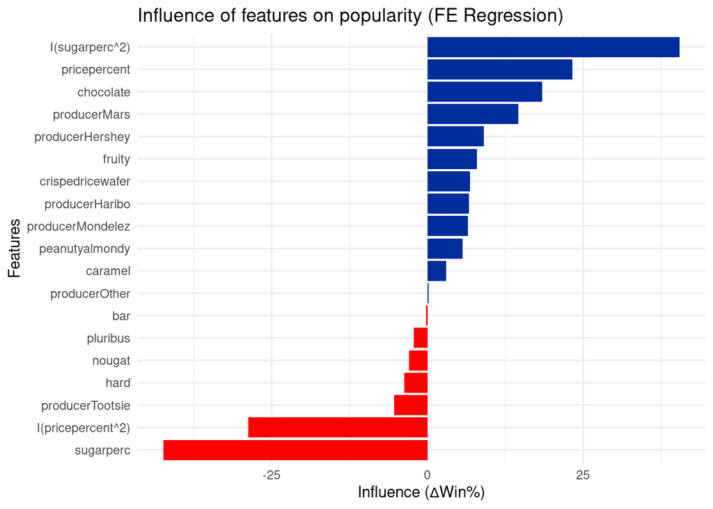

```r
# Visualization of coefficients
coef_df <- as.data.frame(coef(lm_model)[-1]) %>% rownames_to_column("Feature")
names(coef_df)[2] <- "Estimate"
ggplot(coef_df, aes(x = reorder(Feature, Estimate), y = Estimate, fill = Estimate > 0)) +
  geom_col() +
  coord_flip() +
  scale_fill_manual(values = c("red", "#002D9C")) +
  labs(title = "Influence of features on popularity (FE Regression)", x = "Features", y = "Influence (∆Win%)") +
  theme_minimal() +
  theme(legend.position = "none")
```